# Survival Rate

### Working Document

Things Need To DO:

1. More Theory of Surival Analysis
2. Create a dumbell chart
3. Limitations
4. Check Grammar

### Introduction

Survival Rate is a method in which we can measure the time of a an event from the start to finish.

### Loading the Libraries

```r
#install packages
#install.packages('survival') #installed on 12/3/22
#install.packages('ggpubr') installed on 12/3/22
#install.packages('skimr') #installed on 12/4/22

library(survival)
library(tidyverse)
library(ggpubr)
library(skimr)
library(ggpubr)
```

### Loading the Data

```r
#view the names of the dataset in Survival package
print(data(package = "survival"))
```

[output not shown]

So we see that the package has a bunch of datasets we can work with. So, let’s choose the cancer dataset and view it. Let’s store the dataset into a new object, data, for data cleaning.

```r
#see the structure of the dataset
str(cancer)
```

```
'data.frame':   228 obs. of  10 variables:
 $ inst     : num  3 3 3 5 1 12 7 11 1 7 ...
 $ time     : num  306 455 1010 210 883 ...
 $ status   : num  2 2 1 2 2 1 2 2 2 2 ...
 $ age      : num  74 68 56 57 60 74 68 71 53 61 ...
 $ sex      : num  1 1 1 1 1 1 2 2 1 1 ...
 $ ph.ecog  : num  1 0 0 1 0 1 2 2 1 2 ...
 $ ph.karno : num  90 90 90 90 100 50 70 60 70 70 ...
 $ pat.karno: num  100 90 90 60 90 80 60 80 80 70 ...
 $ meal.cal : num  1175 1225 NA 1150 NA ...
 $ wt.loss  : num  NA 15 15 11 0 0 10 1 16 34 ...
```

```r
#provides more info about the dataset and the variables, which allows for
#better data cleaning
?cancer

#store cancer dataset into a new object for data manipulation
data <- cancer
```

### Cleaning the Data

There are a couple tasks that needs to be done.

First, we need to delete the number of NA values. Because each observation is an individual, it is best to delete the obersvation to get the dataset tidy. It is also not best to find take the average of some sort unlike business data (i.e. monthly profit).

Second, we need to convert the variables into appropoate classes based on the data description in ?cancer. For example the variable status is a number and needs to convereted to a factor.

```r
#Count the number of NAs in the dataframe
sum((is.na(data)))
```

```
[1] 67
```

We have 67 NA values within out dataset. Let’s use another method to locate the speicific row and location where we might find these values.

```r
#find out specific observations in which there are NAs
which(is.na(data), arr.ind=TRUE)
```

```
    row col
156 156   1
14   14   6
206 206   7
67   67   8
79   79   8
105 105   8
3     3   9
5     5   9
12   12   9
13   13   9
16   16   9
23   23   9
25   25   9
33   33   9
```

[output cut: 53 more lines]

```r
#count the number of NAs within each column
colSums(is.na(data))
```

```
     inst      time    status       age       sex   ph.ecog  ph.karno pat.karno  meal.cal   wt.loss
        1         0         0         0         0         1         1         3        47        14
```

This is interesting. We see that majority of the NAs are in columns are in meal.cal and wt.loss. The most important variables for the survival analysis are time and status which have no NAs. Much data analysis is usually done with complete datasets, so in our case, I will delete rows that contain NAs and work wit that data set.

```r
#delete all the rows with NAs
data2 <- na.omit(data)

#count the number of NAs within each column
colSums(is.na(data2))
```

```
     inst      time    status       age       sex   ph.ecog  ph.karno pat.karno  meal.cal   wt.loss
        0         0         0         0         0         0         0         0         0         0
```

```r
#creat list of variable names into a object
names <- c('status', 'sex', 'ph.ecog')

#convert some of the variabes to appropiate classes using 1 line of code
data2[names] <- lapply(data2[names], factor)

#check str again
sapply(data2, class)
```

```
     inst      time    status       age       sex   ph.ecog  ph.karno pat.karno  meal.cal   wt.loss
"numeric" "numeric"  "factor" "numeric"  "factor"  "factor" "numeric" "numeric" "numeric" "numeric"
```

```r
#get rid of irrelevant coumns
data2 <- data2[,-1]
```

Great! We have correctly cleaned out data and now let’s move on the the best part, EDA!

### Exploratory Data Analysis

Let’s review some of the basic summary statistics via a new function, skimr.

```r
#a function to call summary statistics
skim(data2)
```

```
── Data Summary ────────────────────────
                           Values
Name                       data2
Number of rows             167
Number of columns          9
_______________________
Column type frequency:
  factor                   3
  numeric                  6
________________________
Group variables            None
```

|  | skim_variable | n_missing | complete_rate | ordered | n_unique | top_counts |
| --- | --- | --- | --- | --- | --- | --- |
| 1 | status | 0 | 1 | FALSE | 2 | 2: 120, 1: 47 |
| 2 | sex | 0 | 1 | FALSE | 2 | 1: 103, 2: 64 |
| 3 | ph.ecog | 0 | 1 | FALSE | 4 | 1: 81, 0: 47, 2: 38, 3: 1 |

|  | skim_variable | n_missing | complete_rate | mean | sd | p0 | p25 | p50 | p75 | p100 | hist |
| --- | --- | --- | --- | --- | --- | --- | --- | --- | --- | --- | --- |
| 1 | time | 0 | 1 | 309.934132 | 209.435591 | 5 | 174.5 | 268 | 419.5 | 1022 | ▇▇▃▂▁ |
| 2 | age | 0 | 1 | 62.568862 | 9.210706 | 39 | 57.0 | 64 | 70.0 | 82 | ▂▅▇▇▃ |
| 3 | ph.karno | 0 | 1 | 82.035928 | 12.778885 | 50 | 70.0 | 80 | 90.0 | 100 | ▃▃▇▇▅ |
| 4 | pat.karno | 0 | 1 | 79.580838 | 15.104188 | 30 | 70.0 | 80 | 90.0 | 100 | ▁▁▆▅▇ |
| 5 | meal.cal | 0 | 1 | 929.125749 | 413.489837 | 96 | 619.0 | 975 | 1162.5 | 2600 | ▅▇▅▁▁ |
| 6 | wt.loss | 0 | 1 | 9.718563 | 13.378587 | -24 | 0.0 | 7 | 15.0 | 68 | ▁▇▃▁▁ |

Although the mean age is 63, let’s split this into men and women.

This is interesting because both men and women have different calorie intake because the naturally difference in body composition. However, when diagnosed with cancer this could change So in the next steps, lets plot those distribution.

Another interesting thing is the weight loss. It would be interested to see how their calories differ as well as the weight loss. So let’s plot those.

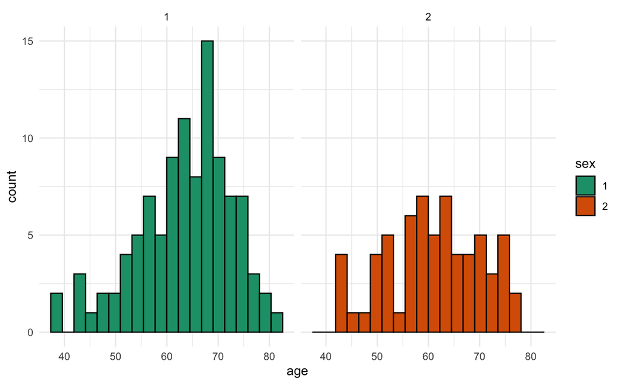

```r
#histogram of men and women ages
ggplot(data2, aes(x=age, group=sex, fill=sex)) +
  geom_histogram(bins = 20, color= 'black') +
  scale_fill_brewer(palette="Dark2") +
  facet_wrap(~sex) +
  theme_minimal()
```

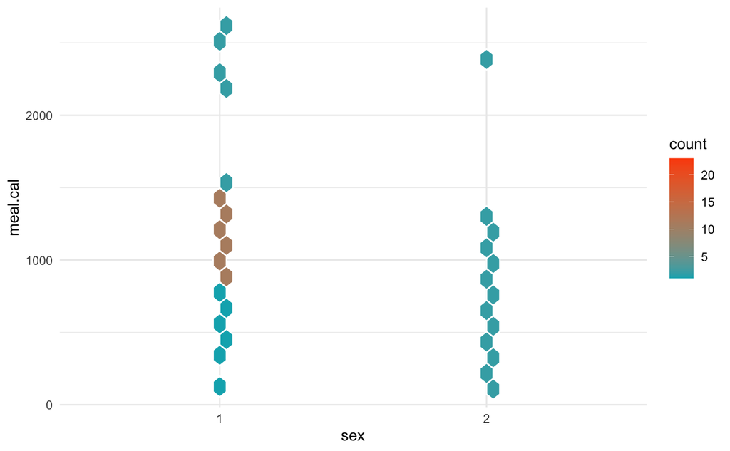

```r
ggplot(data2, aes(sex, meal.cal)) +
  geom_hex(bins = 20, color = "white")+
  #NEED TO CHANGE COLORS
  scale_fill_gradient(low =  "#00AFBB", high = "#FC4E07")+
  theme_minimal()
```

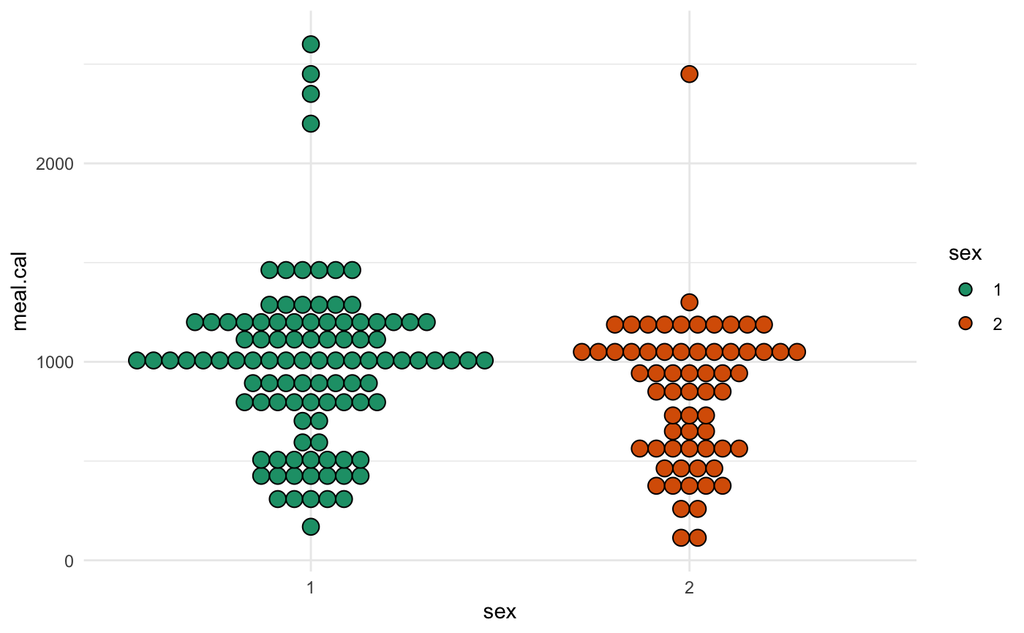

```r
ggplot(data2, aes(x = sex, y= meal.cal, fill = sex)) +
 geom_dotplot(binaxis='y', stackdir='center') +
  scale_fill_brewer(palette="Dark2") +
  theme_minimal()
```

Because we are working with a small dataset, we can use a dotplot to see the number of calories both sexes had during the experiment. It seems they had roughly ~1000 calrories for both groups. (Boxplot is in the appendix).

```r
data2 %>%
  group_by(sex) %>%
  summarize(mean(meal.cal))
```

| sex | mean(meal.cal) |
| --- | --- |
| 1 | 984.7087 |
| 2 | 839.6719 |

We see that the males have a slight higher meal calories than the females.

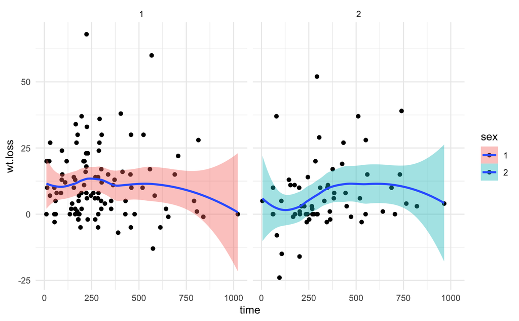

```r
ggplot(data2, aes(x=time, y=wt.loss, fill=sex)) +
  geom_point() +
  geom_smooth() +
  facet_wrap(~sex) +
  theme_minimal()
```

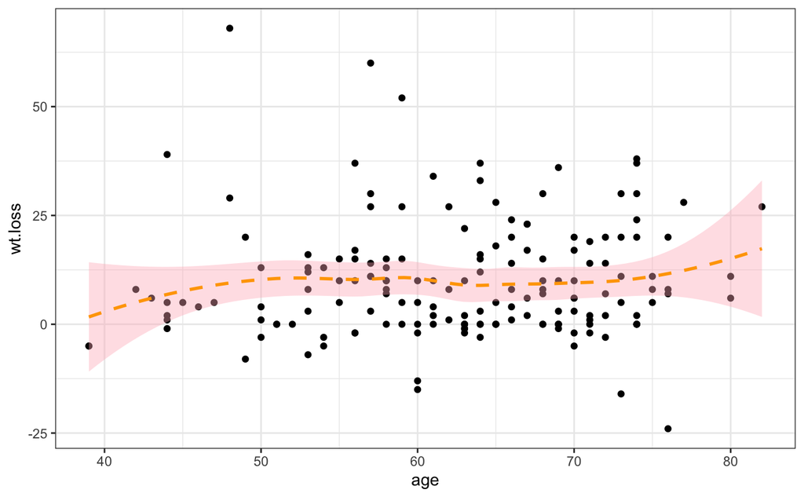

```r
ggplot(data2, aes(x=age, y=wt.loss)) +
  geom_point() +
  geom_smooth(linetype="dashed",
             color="orange", fill="lightpink") +
  theme_bw()
```

### Appendix

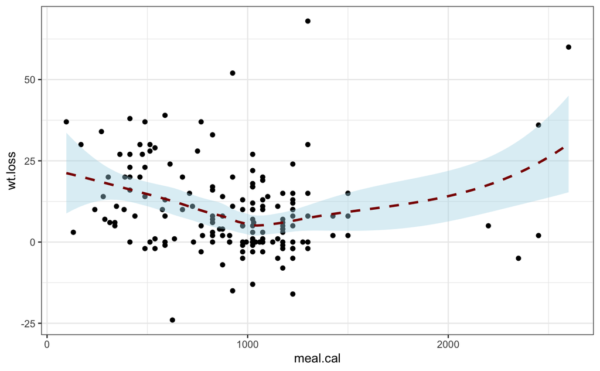

```r
ggplot(data2, aes(x=meal.cal, y=wt.loss)) +
  geom_point() +
  geom_smooth(linetype="dashed",
             color="darkred", fill="lightblue") +
  theme_bw()
```

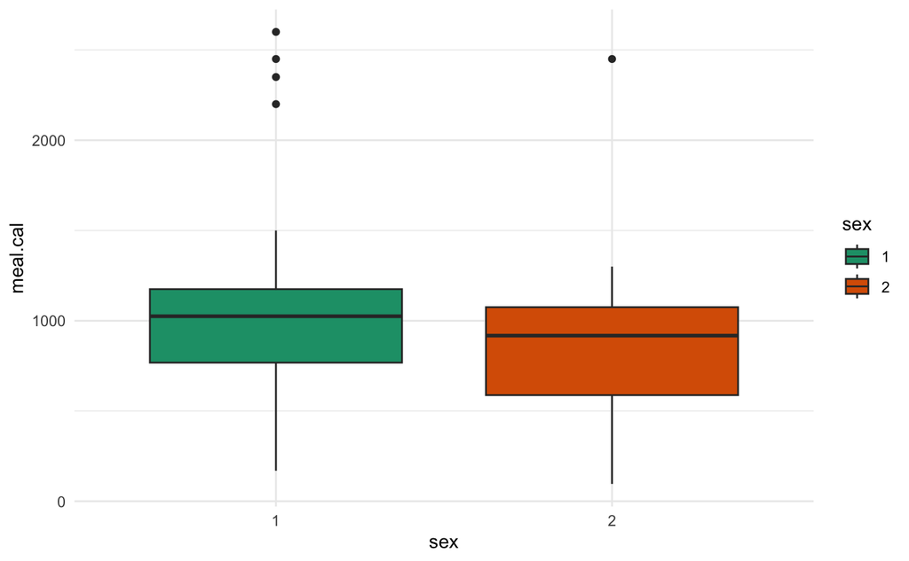

```r
ggplot(data2, aes(sex, meal.cal, fill= sex)) +
  geom_boxplot() +
  scale_fill_brewer(palette="Dark2") +
  theme_minimal()
```